# Reproducible Research: Peer Assessment 1

## Loading and preprocessing the data

I have forked Roger’s [GitHub repository](https://github.com/dnrichardson/RepData_PeerAssessment1) and therefore have the data for this assignment read to go. It’s currently in a zip file, which we will now decompress.

```r
## Check current working directory
getwd()
```

```
## [1] "/Users/dharma/Coursera/Reproducible_Research/RepData_PeerAssessment1"
```

```r
## List the files
list.files()
```

```
##  [1] "activity.csv"                  "activity.zip"
##  [3] "doc"                           "instructions_fig"
##  [5] "PA1_template_files"            "PA1_template.html"
##  [7] "PA1_template.md"               "PA1_template.Rmd"
##  [9] "PeerAssignment1_files"         "PeerAssignment1.html"
## [11] "PeerAssignment1.md"            "PeerAssignment1.Rmd"
## [13] "README.md"                     "RepData_PeerAssessment1.Rproj"
```

```r
## Unzip the activity.zip file if necessary
if (!file.exists("activity.csv")){
        unzip("activity.zip")
}
```

Now, let’s read in the data. But first, let’s check what the first 2 lines look like.

```r
## Read the first couple of lines
readLines(con = file("activity.csv", "r"), n = 2)
```

```
## [1] "\"steps\",\"date\",\"interval\"" "NA,\"2012-10-01\",0"
```

```r
## File looks good and has a header. Read it in and specify the column classes
activity <- read.csv("activity.csv", header = TRUE, stringsAsFactors = FALSE,
                     colClasses = c("integer", "Date", "integer"))
## Check the first lines
head(activity)
```

```
##   steps       date interval
## 1    NA 2012-10-01        0
## 2    NA 2012-10-01        5
## 3    NA 2012-10-01       10
## 4    NA 2012-10-01       15
## 5    NA 2012-10-01       20
## 6    NA 2012-10-01       25
```

```r
## Check the last lines
tail(activity)
```

```
##       steps       date interval
## 17563    NA 2012-11-30     2330
## 17564    NA 2012-11-30     2335
## 17565    NA 2012-11-30     2340
## 17566    NA 2012-11-30     2345
## 17567    NA 2012-11-30     2350
## 17568    NA 2012-11-30     2355
```

Looks like there are a lot of NAs in the steps variable. Let’s quickly check if we actually have step data

```r
sum(activity$steps, na.rm = TRUE)
```

```
## [1] 570608
```

Okay, looks good. Let’s proceed. At this point I am going to load up dplyr and convert the activty dataframe to a tibble.

```r
require(dplyr, quietly = TRUE, warn.conflicts = FALSE)

activity <- tbl_df(activity)
```

## What is mean total number of steps taken per day?

#### Calculate the mean number of steps per day using tapply.

```r
## Try with tapply
totStepsByDay <- tapply(activity$steps, activity$date, sum, na.rm=TRUE)

mean(totStepsByDay)
```

```
## [1] 9354.23
```

```r
median(totStepsByDay)
```

```
## [1] 10395
```

Mean total number of steps per day are 9354 and the median is 10395.

Now, let’s create a histogram of the total number of steps taken each day. We will use base R plotting.

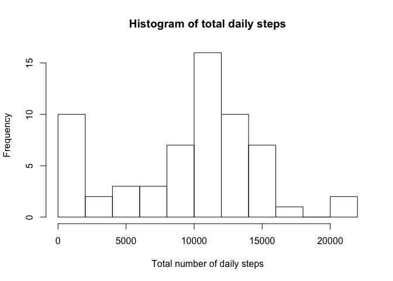

```r
## Calculate total steps per day and convert to data frame
totSteps <- as.data.frame.table(tapply(activity$steps, activity$date, sum, na.rm = TRUE))

## Reconvert the date column to the class Date; note that the date variable was renamed to "Var1"
## by the as.data.frame.table function above
totSteps$Var1 <- as.Date(totSteps$Var1)

## Plot the histogram
hist(totSteps$Freq, breaks = 10, xlab = "Total number of daily steps", main = "Histogram of total daily steps")
```

## What is the average daily activity pattern?

Make a time series plot (i.e. 𝚝𝚢𝚙𝚎 = “𝚕”) of the 5-minute interval (x-axis) and the average number of steps taken, averaged across all days (y-axis)

This will require me to calulate the average number of steps taken across all days for each interval.

```r
## Use tapply again
meanStepsbyIntervals <- as.data.frame.table(tapply(activity$steps, activity$interval, mean, na.rm = TRUE)) %>%
        dplyr::rename(myinterval = Var1, mean = Freq)

## Check first lines
head(meanStepsbyIntervals)
```

```
##   myinterval      mean
## 1          0 1.7169811
## 2          5 0.3396226
## 3         10 0.1320755
## 4         15 0.1509434
## 5         20 0.0754717
## 6         25 2.0943396
```

Double check that I indeed calculated the mean for each interval. Check intervals 0 and 5 with dplyr:

```r
mean(filter(activity, interval == 0)$steps, na.rm = TRUE)
```

```
## [1] 1.716981
```

```r
mean(filter(activity, interval == 5)$steps, na.rm = TRUE)
```

```
## [1] 0.3396226
```

#### Time series plot with ggplot2

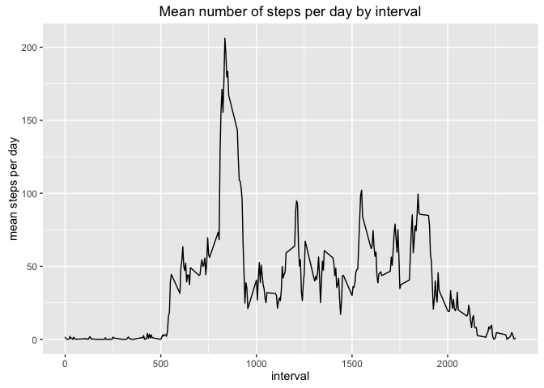

```r
## load ggplot2
require(ggplot2, quietly = TRUE)
require(scales, quietly = TRUE)

## Interval on the x axis and average steps taken on the y

ggplot(data = meanStepsbyIntervals, aes(x = as.numeric(as.character(myinterval)), y = mean, group = 1)) + geom_line(na.rm = TRUE) + labs(title = "Mean number of steps per day by interval", x = "interval",
                                                                                                                                         y = "mean steps per day")
```

Hmm.. The plot is nice, but it’s hard to decipher what the maximum point is just from the plot.

```r
## Get max interval
meanStepsbyIntervals[which.max(meanStepsbyIntervals$mean),]
```

```
##     myinterval     mean
## 104        835 206.1698
```

The interval with the max steps is 835 and this corresponds to roughly 206 steps.

Though we can also try getting these values with an interactive graph using plotly. Note, to see this interactive plot, you will need to view the knitted HTML document in your browswer. You’ll have to download it from my github repo and open it with your browser.

#### Interactive time series plot made with Plotly.

```r
require(plotly, quietly = TRUE, warn.conflicts = FALSE)

xaxis <- list(title = "Interval",
              tickangle = 45
              )

plot_ly(meanStepsbyIntervals, x = ~myinterval, y = ~mean, type = "scatter", mode = "lines") %>%
        layout(title = "Mean steps per day across all days according to Interval", xaxis = xaxis)
```

[interactive chart not shown]

Ahh, that is SOOO much better (and interactive, too)! Note: If you are not currently looking at the HTML version of this file, you will not see the above plot! You must be looking at the knitted HTML document to see the interactive plot above.

#### Which 5-minute interval, on average across all the days in the dataset, contains the maximum number of steps?

From the graph above, the answer to this question is **interval 835, which has roughly 206 average steps**.

## Imputing missing values

Calculate and report the total number of missing values in the dataset (i.e. the total number of rows with 𝙽𝙰s)

```r
## Count up the total number of rows with NAs using base R
nrow(activity[activity$steps == "NA",])
```

```
## [1] 2304
```

```r
## Double check using dplyr
nrow(filter(activity, is.na(steps)))
```

```
## [1] 2304
```

Ok, so it looks like there are **2304 rows** with missing values.

Let’s now devise a simple strategy to impute the missing data. I’ll use the mean of the 5 minute interval across all days to fill in the missing value at the interval in question. Hmm. I may need to write a function to do this. But first, I’ll try the quick and dirty way.

```r
## Simply cbind the the meanStepsbyIntervals to the activity dataframe
activity2 <- cbind(activity, meanStepsbyIntervals)

head(activity2)
```

```
##   steps       date interval myinterval      mean
## 1    NA 2012-10-01        0          0 1.7169811
## 2    NA 2012-10-01        5          5 0.3396226
## 3    NA 2012-10-01       10         10 0.1320755
## 4    NA 2012-10-01       15         15 0.1509434
## 5    NA 2012-10-01       20         20 0.0754717
## 6    NA 2012-10-01       25         25 2.0943396
```

Now, let’s impute the missing values by simply checking if steps is NA and if it is, replacing that NA with the mean.

```r
## Replace the NAs with the mean values
activity2[is.na(activity2$steps),]$steps <- activity2[is.na(activity2$steps),]$mean
head(activity2)
```

```
##       steps       date interval myinterval      mean
## 1 1.7169811 2012-10-01        0          0 1.7169811
## 2 0.3396226 2012-10-01        5          5 0.3396226
## 3 0.1320755 2012-10-01       10         10 0.1320755
## 4 0.1509434 2012-10-01       15         15 0.1509434
## 5 0.0754717 2012-10-01       20         20 0.0754717
## 6 2.0943396 2012-10-01       25         25 2.0943396
```

Now, I need to do the following:

Make a histogram of the total number of steps taken each day and Calculate and report the mean and median total number of steps taken per day. Do these values differ from the estimates from the first part of the assignment? What is the impact of imputing missing data on the estimates of the total daily number of steps?

For this, I can reuse the code I already created in the beginning of the document.

#### Calculate the mean steps per day

```r
## Try with tapply

totStepsByDay2 <- tapply(activity2$steps, activity2$date, sum, na.rm=TRUE)

mean(totStepsByDay2)
```

```
## [1] 10766.19
```

```r
median(totStepsByDay2)
```

```
## [1] 10766.19
```

Looks like that worked. R is amazing! Looks like the mean and median are exactly the same now after imputation.

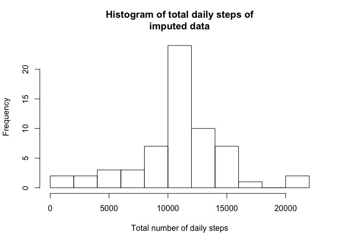

```r
## Calculate total steps per day and convert to data frame
totSteps2 <- as.data.frame.table(tapply(activity2$steps, activity2$date, sum, na.rm = TRUE))

## Reconvert the date column to the class Date; note that the date variable was renamed to "Var1"
## by the as.data.frame.table function above
totSteps2$Var1 <- as.Date(totSteps2$Var1)

## Plot the histogram
hist(totSteps2$Freq, breaks = 10, xlab = "Total number of daily steps", main = "Histogram of total daily steps of
imputed data")
```

## Are there differences in activity patterns between weekdays and weekends?

Create a temporary variable, called “day”, which stores the output of the weekdays() function. Then create a new factor variable called, “weekday”, that will have two levels, “weekday” and “weekend”. Note, I will be using the imputed data frame as there was no specification in the assingment instructions of which to use.

```r
## Create day variable
activity2$day <- weekdays(activity2$date)
head(activity2)
```

```
##       steps       date interval myinterval      mean    day
## 1 1.7169811 2012-10-01        0          0 1.7169811 Monday
## 2 0.3396226 2012-10-01        5          5 0.3396226 Monday
## 3 0.1320755 2012-10-01       10         10 0.1320755 Monday
## 4 0.1509434 2012-10-01       15         15 0.1509434 Monday
## 5 0.0754717 2012-10-01       20         20 0.0754717 Monday
## 6 2.0943396 2012-10-01       25         25 2.0943396 Monday
```

```r
## Create weekday factor variable

activity2 <- activity2 %>% mutate(weekday = ifelse(day == "Saturday" | day == "Sunday", "weekend", ifelse(day != "Saturday" | day != "Sunday", "weekday")))

activity2$weekday <- factor(activity2$weekday, levels = c("weekday", "weekend"))

head(activity2)
```

```
##       steps       date interval myinterval      mean    day weekday
## 1 1.7169811 2012-10-01        0          0 1.7169811 Monday weekday
## 2 0.3396226 2012-10-01        5          5 0.3396226 Monday weekday
## 3 0.1320755 2012-10-01       10         10 0.1320755 Monday weekday
## 4 0.1509434 2012-10-01       15         15 0.1509434 Monday weekday
## 5 0.0754717 2012-10-01       20         20 0.0754717 Monday weekday
## 6 2.0943396 2012-10-01       25         25 2.0943396 Monday weekday
```

Finally, we can make our last plot. This assignment was estimated to take 2 hours, but I’ve spent more like 5 hours on it.

```r
## Create two new dataframes based on factor
weekdays <- activity2[activity2$weekday == "weekday",]
weekends <- activity2[activity2$weekday == "weekend",]

## Create two new dataframes of interval means
meanStepsbyIntervalsWeekdays <- as.data.frame.table(tapply(weekdays$steps, weekdays$interval, mean, na.rm = TRUE)) %>%
        dplyr::rename(myinterval = Var1, mean = Freq)

meanStepsbyIntervalsWeekends <- as.data.frame.table(tapply(weekends$steps, weekends$interval, mean, na.rm = TRUE)) %>%
        dplyr::rename(myinterval = Var1, mean = Freq)

## Add the weekend variable to facet by
meanStepsbyIntervalsWeekdays$weekday <- "weekday"
meanStepsbyIntervalsWeekends$weekday <- "weekend"

## rbind them
myIntervalData <- rbind(meanStepsbyIntervalsWeekdays, meanStepsbyIntervalsWeekends)
```

#### Facet plot of mean steps per day by interval

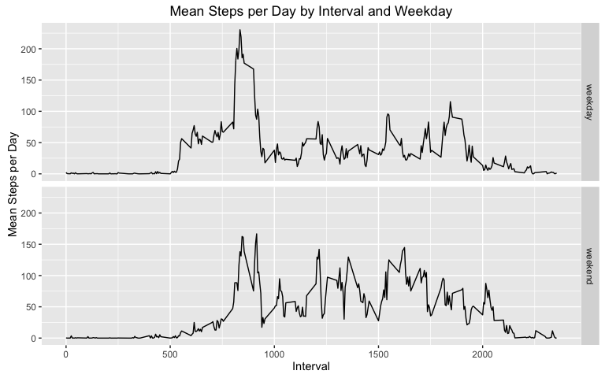

```r
## Interval on the x axis and average steps taken on the y
ggplot(data = myIntervalData, aes(x = as.numeric(as.character(myIntervalData$myinterval)), y = mean, group = 1)) + geom_line(na.rm = TRUE) +
        facet_grid(weekday ~.) + labs(x = "Interval", y = "Mean Steps per Day", title = "Mean Steps per Day by Interval and Weekday")
```

Indeed, it looks like activity levels are slightly higher in the intervals after 1000, but are lower in the intervals below 1000.